# Causal Impact on Leads Generation

Ahmad Fauzi

2024-02-20

# Background

In the business process, the marketing team plays a crucial role in raising awareness of a product in the market. The success of marketing efforts is often measured by the number of leads generated. In a digital context, “leads” refer to individuals who show interest in a product or service through various online actions such as visiting a website, interacting with an ad, or sharing marketing content.

This process begins when the marketing team successfully captures the attention of potential customers and sparks their interest. The next step is to capture their contact information and direct them to the sales team for further follow-up. There are various strategies that can be used to generate “leads”, from creating engaging content, doing various forms of advertising, to providing incentives such as promo codes or e-books.

Thus, marketing efforts not only aim to increase brand awareness, but also to gather leads that can be converted into potential customers through the right marketing measures.

# Modeling

```r
library(tidyverse)
library(CausalImpact)
library(readxl)
library(forecast)
library(TSstudio)
library(lubridate)
```

The data comes from the results of a website **googleanalytics**. For post-period modeling, the previous 37 days will be used as training data. The business question is that on the next day, after the campaign conducted, is it getting a significant increase in leads?

```r
data <- read_csv("http://bit.ly/causal-impact-data")

glimpse(data)
```

```
#> Rows: 54
#> Columns: 9
#> $ page              <chr> "9fb22be32c347a5acd1d3724b0dae726", "9fb22be32c347a5…
#> $ datetime          <dbl> 20180516, 20180517, 20180518, 20180519, 20180520, 20…
#> $ page_display      <dbl> 0, 0, 0, 0, 0, 0, 0, 0, 0, 0, 0, 0, 0, 0, 0, 0, 0, 0…
#> $ unique_views      <dbl> 1456, 1392, 1281, 658, 616, 1691, 1488, 1316, 1224, …
#> $ average_page_time <dbl> 0, 0, 0, 0, 0, 0, 0, 0, 0, 0, 0, 0, 0, 0, 0, 0, 0, 0…
#> $ tickets           <dbl> 0, 0, 0, 0, 0, 0, 0, 0, 0, 0, 0, 0, 0, 0, 0, 0, 0, 0…
#> $ bounce_rate       <dbl> 0, 0, 0, 0, 0, 0, 0, 0, 0, 0, 0, 0, 0, 0, 0, 0, 0, 0…
#> $ exit_percentage   <dbl> 0, 0, 0, 0, 0, 0, 0, 0, 0, 0, 0, 0, 0, 0, 0, 0, 0, 0…
#> $ page_value        <dbl> 0, 0, 0, 0, 0, 0, 0, 0, 0, 0, 0, 0, 0, 0, 0, 0, 0, 0…
```

We select several columns that are the focus of this analysis, `datetime` (daily) and `unique views` which contain information on how many people visited the website page.

```r
actual <- data %>%
  mutate(
    datetime = lubridate::as_datetime(as.character(datetime))
  ) %>%
  dplyr::select(datetime, unique_views) %>%
  na.omit()

head(actual)
```

| datetime | unique_views |
| --- | --- |
| 2018-05-16 | 1456 |
| 2018-05-17 | 1392 |
| 2018-05-18 | 1281 |
| 2018-05-19 | 658 |
| 2018-05-20 | 616 |
| 2018-05-21 | 1691 |

```r
range(actual$datetime)
```

```
#> [1] "2018-05-16 UTC" "2018-07-10 UTC"
```

> Next we will do some exploratory analysis, which day is the most leads generation?

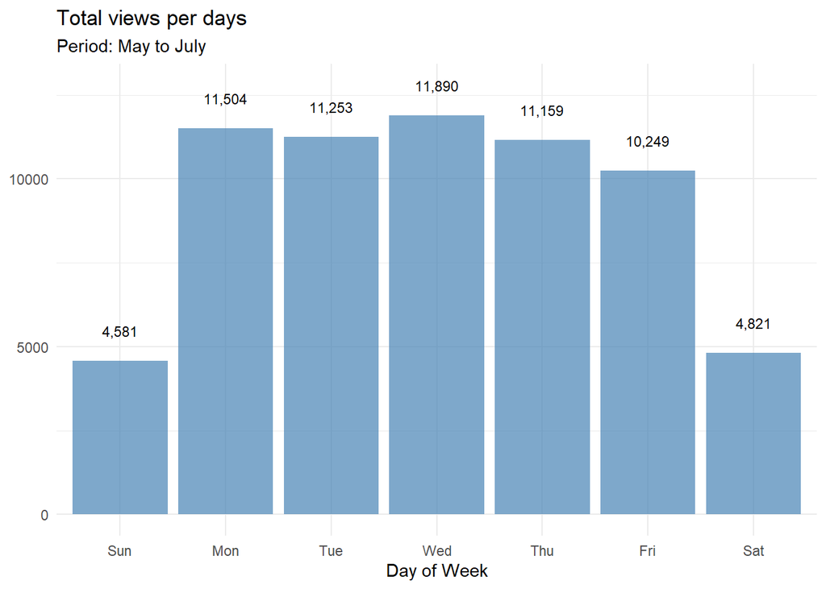

```r
actual %>%
  mutate(
    wdays = lubridate::wday(datetime, label = TRUE)
  ) %>%
  group_by(wdays) %>%
  summarise(total_views = sum(unique_views)) %>%
  ungroup() %>%
  mutate(
    label = scales::comma(total_views)
  ) %>%
  ggplot(
    mapping = aes(x = wdays, y = total_views)
  ) +
  geom_col(fill = "steelblue", alpha  = 0.7) +
  labs(
    title = "Total views per days",
    subtitle = "Period: May to July",
    y = NULL,
    x = "Day of Week"
  ) +
  geom_text(
    aes(label = label, y = total_views + max(total_views) * 0.075) , size = 3
  ) +
  theme_minimal()
```

Leads generation is highest on Wednesday. This information can be taken into consideration in determining the day to start the campaign.